# Assignment 3

Author

Giuliet Kibler

## Due Date

This assignment is due by 11:59pm Pacific Time, November 8th, 2024.

```r
# Load in data
data <- read.csv("pubmed.csv")
```

## Text Mining

A new dataset has been added to the data science data repository https://github.com/USCbiostats/data-science-data/tree/master/03_pubmed. The dataset contains 3,241 abstracts from articles collected via 5 PubMed searches. The search terms are listed in the second column, `term` and these will serve as the “documents.” Your job is to analyse these abstracts to find interesting insights.

1. Tokenize the abstracts and count the number of each token. Do you see anything interesting? Does removing stop words change what tokens appear as the most frequent? What are the 5 most common tokens for each search term after removing stopwords?

   ```r
   # Tokenize the abstracts
   tokenized_data <- data |>
     unnest_tokens(word, abstract)

   # Display the tokenized data
   tokenized_data |>
     count(word, sort = TRUE) |>
     top_n(10, n)
   ```

   ```
       word     n
   1    the 28126
   2     of 24760
   3    and 19993
   4     in 14653
   5     to 10920
   6      a  8245
   7   with  8038
   8  covid  7275
   9     19  7080
   10    is  5649
   ```

   Top words are mostly stop words and covid and 19, which is not interesting.

   ```r
   # Remove stop words
   data("stop_words")
   token_counts_cleaned <- tokenized_data |>
     anti_join(stop_words, by = "word") |>
     count(term, word, sort = TRUE)

   # Top 5 words after removing stop words
   top_tokens_cleaned <- token_counts_cleaned |>
     group_by(term) |>
     top_n(5, n) |>
     arrange(term, desc(n))
   print(top_tokens_cleaned)
   ```

   ```
   # A tibble: 25 × 3
   # Groups:   term [5]
      term            word         n
      <chr>           <chr>    <int>
    1 covid           covid     7275
    2 covid           19        7035
    3 covid           patients  2293
    4 covid           disease    943
    5 covid           pandemic   800
    6 cystic fibrosis fibrosis   867
    7 cystic fibrosis cystic     862
    8 cystic fibrosis cf         625
    9 cystic fibrosis patients   586
   10 cystic fibrosis disease    400
   # ℹ 15 more rows
   ```

   Now there is some interest in the data with most terms related to medical terms. The top 5 words for each search term are also highly related to their search term, with many including the search term and other medical terms.
2. Tokenize the abstracts into bigrams. Find the 10 most common bigrams and visualize them with ggplot2.

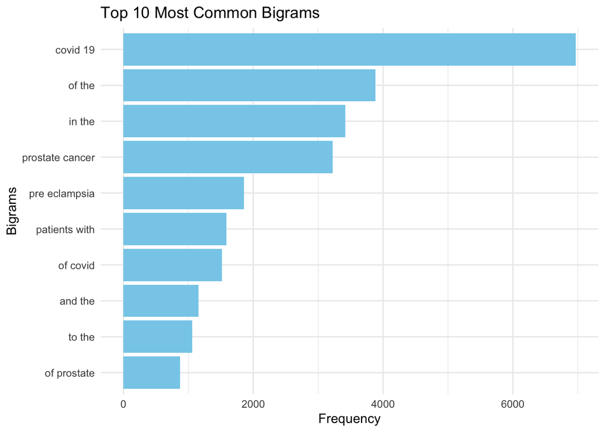

   ```r
   # Tokenize into bigrams
   bigram_data <- data |>
     unnest_tokens(bigram, abstract, token = "ngrams", n = 2)  # n = 2 for bigrams

   # Count the frequency of each bigram
   bigram_counts <- bigram_data |>
     count(bigram, sort = TRUE)

   # Find the top 10 bigrams
   top_bigrams <- bigram_counts|>
     top_n(10, n)

   # Plot the top 10 bigrams
   ggplot(top_bigrams, aes(x = reorder(bigram, n), y = n)) +
     geom_col(fill = "skyblue") +
     labs(title = "Top 10 Most Common Bigrams",
          x = "Bigrams",
          y = "Frequency") +
     coord_flip() +  # Flip coordinates for better readability
     theme_minimal()
   ```

3. Calculate the TF-IDF value for each word-search term combination (here you want the search term to be the “document”). What are the 5 tokens from each search term with the highest TF-IDF value? How are the results different from the answers you got in question 1?

   ```r
   # Calculate TF-IDF
   tf_idf_data <- tokenized_data|>
     count(term, word) |>
     bind_tf_idf(word, term, n)

   # Get top 5 tokens by TF-IDF for each search term
   top_tf_idf <- tf_idf_data |>
     group_by(term) |>
     top_n(5, wt = tf_idf) |>
     arrange(term, desc(tf_idf))
   print(top_tf_idf)
   ```

   ```
   # A tibble: 25 × 6
   # Groups:   term [5]
      term            word            n      tf   idf  tf_idf
      <chr>           <chr>       <int>   <dbl> <dbl>   <dbl>
    1 covid           covid        7275 0.0371  1.61  0.0597
    2 covid           pandemic      800 0.00408 1.61  0.00657
    3 covid           coronavirus   647 0.00330 1.61  0.00531
    4 covid           sars          372 0.00190 1.61  0.00305
    5 covid           cov           334 0.00170 1.61  0.00274
    6 cystic fibrosis cf            625 0.0127  0.916 0.0117
    7 cystic fibrosis fibrosis      867 0.0176  0.511 0.00901
    8 cystic fibrosis cystic        862 0.0175  0.511 0.00896
    9 cystic fibrosis cftr           86 0.00175 1.61  0.00282
   10 cystic fibrosis sweat          83 0.00169 1.61  0.00272
   # ℹ 15 more rows
   ```

   For Covid, the top 5 overall words were covid, 19, patients, disease, and pandemic. Covid and pandemic remain in the TF-IDF top words, but are accompanied by other covid-19 related words, such as coronavirus, sars, and cov.

   For Cystic fibrosis, the top 5 overall words were fibrosis, cystic, cf, patients, and disease. Cf, fibrosis, and cystic are all in the TF-IDF top words, with the addition of cftr and sweat.

   For Meningitis, the top 5 overall words were patients, meningitis, meningeal, csf, and clinical. Meningitis, meningeal, and csf remain TF-IDF top words, but also include pachymeningitis and meninges.

   For Preeclampsia, the top 5 overall words were pre, eclampsia, preeclampsia, women, and pregnancy. Eclampsia, preeclampsia, and pregnancy remain in the top TF-IDF words with maternal and gestational.

   Finally, for Prostate Cancer, the top 5 overall words were cancer, prostate, patients, treatment, and disease. Prostate is the only word of these top words to also be in the top TF-IDF words with the addition of androgen, psa, prostatectomy, and castration.

   These additional words in the TF-IDF make sense, because they are more specific to the disease of interest by loosing general medical terms.

## Sentiment Analysis

1. Perform a sentiment analysis using the NRC lexicon. What is the most common sentiment for each search term? What if you remove `"positive"` and `"negative"` from the list?

   ```r
   # Load the NRC lexicon
   nrc <- get_sentiments("nrc")
   # Citation: 'http://saifmohammad.com/WebDocs/Lexicons/NRC-Emotion-Lexicon.zip'

   # Join tokenized data with NRC lexicon
   sentiment_data <- tokenized_data |>
     inner_join(nrc, by = "word")

   # Count sentiments by search term
   sentiment_counts <- sentiment_data |>
     count(term, sentiment, sort = TRUE)

   # Most common sentiment for each search term
   most_common_sentiment <- sentiment_counts|>
     group_by(term) |>
     slice_max(n, n = 1) |>
     ungroup()
   print(most_common_sentiment)
   ```

   ```
   # A tibble: 5 × 3
     term            sentiment     n
     <chr>           <chr>     <int>
   1 covid           positive   9874
   2 cystic fibrosis positive   2747
   3 meningitis      negative   2109
   4 preeclampsia    positive   8014
   5 prostate cancer negative   8918
   ```

   Positive is the most common sentiment for covid, cystic fibrosis, and preeclampsia. Negative is the most common sentiment for meningitis and prostate cancer.

   ```r
   # Remove "positive" and "negative" sentiments
   filtered_sentiment_counts <- sentiment_counts |>
     filter(!(sentiment %in% c("positive", "negative")))

   # Most common sentiment after removing positive and negative
   most_common_filtered_sentiment <- filtered_sentiment_counts |>
     group_by(term) |>
     slice_max(n, n = 1) |>
     ungroup()
   print(most_common_filtered_sentiment)
   ```

   ```
   # A tibble: 5 × 3
     term            sentiment        n
     <chr>           <chr>        <int>
   1 covid           fear          7730
   2 cystic fibrosis disgust       1714
   3 meningitis      fear          1510
   4 preeclampsia    anticipation  4780
   5 prostate cancer fear          8118
   ```

   Fear is now the most common sentiment for covid, meningitis, and prostate cancer, while disgust is most common for cystic fibrosis and anticipation is most common for preeclampsia These sentiments are much more meaningful than positive and negative in medical terms because people are often fearful and anxious when they are diagnosed with a disease. Disgust is interesting because it provides insight into what people think of the disease rather than how they feel being diagnosed with it.
2. Now perform a sentiment analysis using the AFINN lexicon to get an average positivity score for each abstract (hint: you may want to create a variable that indexes, or counts, the abstracts). Create a visualization that shows these scores grouped by search term. Are any search terms noticeably different from the others?

   ```r
   # Load the AFINN lexicon
   afinn <- get_sentiments("afinn")
   # Citation: http://www2.imm.dtu.dk/pubdb/views/publication_details.php?id=6010

   # Calculate sentiment scores for each abstract
   sentiment_scores <- data |>
     mutate(abstract_id = row_number()) |>
     unnest_tokens(word, abstract) |>
     inner_join(afinn, by = "word") |>
     group_by(abstract_id, term) |>
     summarise(average_score = mean(value, na.rm = TRUE), .groups = 'drop')
   head(sentiment_scores)
   ```

   ```
   # A tibble: 6 × 3
     abstract_id term  average_score
           <int> <chr>         <dbl>
   1           1 covid        -1.13
   2           2 covid        -2
   3           3 covid         0.214
   4           4 covid        -0.8
   5           5 covid        -1.67
   6           6 covid        -0.143
   ```

   ```r
   # 78 IDs are missing as they are NA (they are likely too short)
   ```

   ```r
   # Calculate average score for each search term
   average_scores_grouped <- sentiment_scores |>
     group_by(term) |>
     summarise(average_pos_score = mean(average_score, na.rm = TRUE), .groups = 'drop')
   print(average_scores_grouped)
   ```

   ```
   # A tibble: 5 × 2
     term            average_pos_score
     <chr>                       <dbl>
   1 covid                      -0.147
   2 cystic fibrosis             0.322
   3 meningitis                 -0.163
   4 preeclampsia               -0.121
   5 prostate cancer            -0.239
   ```

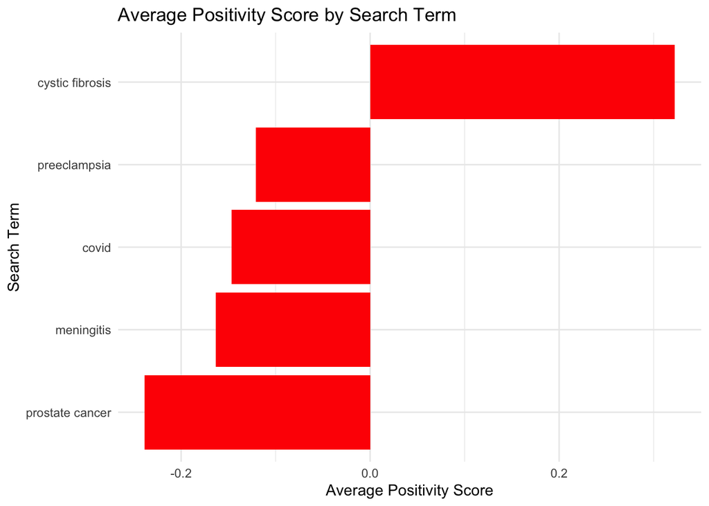

   ```r
   # Visualize the Average Positivity Scores
   ggplot(average_scores_grouped, aes(x = reorder(term, average_pos_score), y = average_pos_score)) +
     geom_col(fill = "red") +
     labs(title = "Average Positivity Score by Search Term",
          x = "Search Term",
          y = "Average Positivity Score") +
     coord_flip() +  # Flip coordinates for better readability
     theme_minimal()
   ```

   Cystic fibrosis is the only search term with a average positive sentiment. Although all have averages between -1 and 1, so the sentiments are relatively neutral for all search terms.